# Risk Factor Analysis

## Outcome Variable

**Outcome Variable:** wasted

## Predictor Variables

**Intervention Variable:** impsan

**Adjustment Set:**

unadjusted

## Stratifying Variables

The analysis was stratified on these variable(s):

- agecat
- studyid
- country

## Data Summary

| agecat | studyid | country | impsan | wasted | n_cell | n | outcome_variable |
| --- | --- | --- | --- | --- | --- | --- | --- |
| Birth | ki0047075b-MAL-ED | BANGLADESH | 1 | 0 | 138 | 201 | wasted |
| Birth | ki0047075b-MAL-ED | BANGLADESH | 1 | 1 | 30 | 201 | wasted |
| Birth | ki0047075b-MAL-ED | BANGLADESH | 0 | 0 | 28 | 201 | wasted |
| Birth | ki0047075b-MAL-ED | BANGLADESH | 0 | 1 | 5 | 201 | wasted |
| Birth | ki0047075b-MAL-ED | BRAZIL | 1 | 0 | 54 | 57 | wasted |
| Birth | ki0047075b-MAL-ED | BRAZIL | 1 | 1 | 2 | 57 | wasted |
| Birth | ki0047075b-MAL-ED | BRAZIL | 0 | 0 | 1 | 57 | wasted |
| Birth | ki0047075b-MAL-ED | BRAZIL | 0 | 1 | 0 | 57 | wasted |
| Birth | ki0047075b-MAL-ED | INDIA | 1 | 0 | 11 | 39 | wasted |
| Birth | ki0047075b-MAL-ED | INDIA | 1 | 1 | 3 | 39 | wasted |
| Birth | ki0047075b-MAL-ED | INDIA | 0 | 0 | 23 | 39 | wasted |
| Birth | ki0047075b-MAL-ED | INDIA | 0 | 1 | 2 | 39 | wasted |
| Birth | ki0047075b-MAL-ED | NEPAL | 1 | 0 | 22 | 25 | wasted |
| Birth | ki0047075b-MAL-ED | NEPAL | 1 | 1 | 2 | 25 | wasted |
| Birth | ki0047075b-MAL-ED | NEPAL | 0 | 0 | 1 | 25 | wasted |
| Birth | ki0047075b-MAL-ED | NEPAL | 0 | 1 | 0 | 25 | wasted |
| Birth | ki0047075b-MAL-ED | PERU | 1 | 0 | 50 | 203 | wasted |
| Birth | ki0047075b-MAL-ED | PERU | 1 | 1 | 0 | 203 | wasted |
| Birth | ki0047075b-MAL-ED | PERU | 0 | 0 | 149 | 203 | wasted |
| Birth | ki0047075b-MAL-ED | PERU | 0 | 1 | 4 | 203 | wasted |
| Birth | ki0047075b-MAL-ED | SOUTH AFRICA | 1 | 0 | 0 | 94 | wasted |
| Birth | ki0047075b-MAL-ED | SOUTH AFRICA | 1 | 1 | 0 | 94 | wasted |
| Birth | ki0047075b-MAL-ED | SOUTH AFRICA | 0 | 0 | 84 | 94 | wasted |
| Birth | ki0047075b-MAL-ED | SOUTH AFRICA | 0 | 1 | 10 | 94 | wasted |
| Birth | ki0047075b-MAL-ED | TANZANIA, UNITED REPUBLIC OF | 1 | 0 | 0 | 110 | wasted |
| Birth | ki0047075b-MAL-ED | TANZANIA, UNITED REPUBLIC OF | 1 | 1 | 0 | 110 | wasted |
| Birth | ki0047075b-MAL-ED | TANZANIA, UNITED REPUBLIC OF | 0 | 0 | 109 | 110 | wasted |
| Birth | ki0047075b-MAL-ED | TANZANIA, UNITED REPUBLIC OF | 0 | 1 | 1 | 110 | wasted |
| Birth | ki1017093-NIH-Birth | BANGLADESH | 1 | 0 | 157 | 575 | wasted |
| Birth | ki1017093-NIH-Birth | BANGLADESH | 1 | 1 | 65 | 575 | wasted |

[output cut: 170 more lines]

The following strata were considered:

- agecat: 24 months, studyid: ki0047075b-MAL-ED, country: BANGLADESH
- agecat: 24 months, studyid: ki0047075b-MAL-ED, country: BRAZIL
- agecat: 24 months, studyid: ki0047075b-MAL-ED, country: INDIA
- agecat: 24 months, studyid: ki0047075b-MAL-ED, country: NEPAL
- agecat: 24 months, studyid: ki0047075b-MAL-ED, country: PERU
- agecat: 24 months, studyid: ki0047075b-MAL-ED, country: SOUTH AFRICA
- agecat: 24 months, studyid: ki0047075b-MAL-ED, country: TANZANIA, UNITED REPUBLIC OF
- agecat: 24 months, studyid: ki1017093-NIH-Birth, country: BANGLADESH
- agecat: 24 months, studyid: ki1017093b-PROVIDE, country: BANGLADESH
- agecat: 24 months, studyid: ki1017093c-NIH-Crypto, country: BANGLADESH
- agecat: 24 months, studyid: ki1114097-CONTENT, country: PERU
- agecat: 24 months, studyid: ki1135781-COHORTS, country: GUATEMALA
- agecat: 24 months, studyid: ki1135781-COHORTS, country: INDIA
- agecat: 24 months, studyid: ki1135781-COHORTS, country: PHILIPPINES
- agecat: 24 months, studyid: ki1148112-LCNI-5, country: MALAWI
- agecat: 24 months, studyid: kiGH5241-JiVitA-3, country: BANGLADESH
- agecat: 24 months, studyid: kiGH5241-JiVitA-4, country: BANGLADESH
- agecat: 6 months, studyid: ki0047075b-MAL-ED, country: BANGLADESH
- agecat: 6 months, studyid: ki0047075b-MAL-ED, country: BRAZIL
- agecat: 6 months, studyid: ki0047075b-MAL-ED, country: INDIA
- agecat: 6 months, studyid: ki0047075b-MAL-ED, country: NEPAL
- agecat: 6 months, studyid: ki0047075b-MAL-ED, country: PERU
- agecat: 6 months, studyid: ki0047075b-MAL-ED, country: SOUTH AFRICA
- agecat: 6 months, studyid: ki0047075b-MAL-ED, country: TANZANIA, UNITED REPUBLIC OF
- agecat: 6 months, studyid: ki1017093-NIH-Birth, country: BANGLADESH
- agecat: 6 months, studyid: ki1017093b-PROVIDE, country: BANGLADESH
- agecat: 6 months, studyid: ki1017093c-NIH-Crypto, country: BANGLADESH
- agecat: 6 months, studyid: ki1114097-CONTENT, country: PERU
- agecat: 6 months, studyid: ki1135781-COHORTS, country: GUATEMALA
- agecat: 6 months, studyid: ki1135781-COHORTS, country: INDIA
- agecat: 6 months, studyid: ki1135781-COHORTS, country: PHILIPPINES
- agecat: 6 months, studyid: ki1148112-LCNI-5, country: MALAWI
- agecat: 6 months, studyid: kiGH5241-JiVitA-3, country: BANGLADESH
- agecat: 6 months, studyid: kiGH5241-JiVitA-4, country: BANGLADESH
- agecat: Birth, studyid: ki0047075b-MAL-ED, country: BANGLADESH
- agecat: Birth, studyid: ki0047075b-MAL-ED, country: BRAZIL
- agecat: Birth, studyid: ki0047075b-MAL-ED, country: INDIA
- agecat: Birth, studyid: ki0047075b-MAL-ED, country: NEPAL
- agecat: Birth, studyid: ki0047075b-MAL-ED, country: PERU
- agecat: Birth, studyid: ki0047075b-MAL-ED, country: SOUTH AFRICA
- agecat: Birth, studyid: ki0047075b-MAL-ED, country: TANZANIA, UNITED REPUBLIC OF
- agecat: Birth, studyid: ki1017093-NIH-Birth, country: BANGLADESH
- agecat: Birth, studyid: ki1017093b-PROVIDE, country: BANGLADESH
- agecat: Birth, studyid: ki1017093c-NIH-Crypto, country: BANGLADESH
- agecat: Birth, studyid: ki1114097-CONTENT, country: PERU
- agecat: Birth, studyid: ki1135781-COHORTS, country: GUATEMALA
- agecat: Birth, studyid: ki1135781-COHORTS, country: INDIA
- agecat: Birth, studyid: ki1135781-COHORTS, country: PHILIPPINES
- agecat: Birth, studyid: kiGH5241-JiVitA-3, country: BANGLADESH
- agecat: Birth, studyid: kiGH5241-JiVitA-4, country: BANGLADESH

### Dropped Strata

Some strata were dropped due to rare outcomes:

- agecat: Birth, studyid: ki0047075b-MAL-ED, country: BRAZIL
- agecat: Birth, studyid: ki0047075b-MAL-ED, country: INDIA
- agecat: Birth, studyid: ki0047075b-MAL-ED, country: NEPAL
- agecat: Birth, studyid: ki0047075b-MAL-ED, country: PERU
- agecat: Birth, studyid: ki0047075b-MAL-ED, country: SOUTH AFRICA
- agecat: Birth, studyid: ki0047075b-MAL-ED, country: TANZANIA, UNITED REPUBLIC OF
- agecat: Birth, studyid: ki1017093b-PROVIDE, country: BANGLADESH
- agecat: Birth, studyid: ki1114097-CONTENT, country: PERU
- agecat: 6 months, studyid: ki0047075b-MAL-ED, country: BANGLADESH
- agecat: 6 months, studyid: ki0047075b-MAL-ED, country: BRAZIL
- agecat: 6 months, studyid: ki0047075b-MAL-ED, country: NEPAL
- agecat: 6 months, studyid: ki0047075b-MAL-ED, country: PERU
- agecat: 6 months, studyid: ki0047075b-MAL-ED, country: SOUTH AFRICA
- agecat: 6 months, studyid: ki0047075b-MAL-ED, country: TANZANIA, UNITED REPUBLIC OF
- agecat: 6 months, studyid: ki1017093b-PROVIDE, country: BANGLADESH
- agecat: 6 months, studyid: ki1114097-CONTENT, country: PERU
- agecat: 6 months, studyid: ki1135781-COHORTS, country: GUATEMALA
- agecat: 6 months, studyid: ki1135781-COHORTS, country: PHILIPPINES
- agecat: 6 months, studyid: ki1148112-LCNI-5, country: MALAWI
- agecat: 24 months, studyid: ki0047075b-MAL-ED, country: BRAZIL
- agecat: 24 months, studyid: ki0047075b-MAL-ED, country: NEPAL
- agecat: 24 months, studyid: ki0047075b-MAL-ED, country: PERU
- agecat: 24 months, studyid: ki0047075b-MAL-ED, country: SOUTH AFRICA
- agecat: 24 months, studyid: ki0047075b-MAL-ED, country: TANZANIA, UNITED REPUBLIC OF
- agecat: 24 months, studyid: ki1017093b-PROVIDE, country: BANGLADESH
- agecat: 24 months, studyid: ki1017093c-NIH-Crypto, country: BANGLADESH
- agecat: 24 months, studyid: ki1114097-CONTENT, country: PERU
- agecat: 24 months, studyid: ki1135781-COHORTS, country: GUATEMALA
- agecat: 24 months, studyid: ki1148112-LCNI-5, country: MALAWI

## Methods Detail

We’re interested in the causal parameters $E[Y_a]$ for all values of $a \in \mathcal{A}$. These parameters represent the mean outcome if, possibly contrary to fact, we intervened to set all units to have $A=a$. Under the randomization and positivity assumptions, these are identified by the statistical parameters $\psi_a=E_W[E_{Y|A,W}(Y|A=a,W)]$. In addition, we’re interested in the mean of $Y$, $E[Y]$ under no intervention (the observed mean). We will estimate these parameters by using SuperLearner to fit the relevant likelihood factors – $E_{Y|A,W}(Y|A=a,W)$ and $p(A=a|W)$, and then updating our likelihood fit using a joint TMLE.

For unadjusted analyses ($W=\{\}$), initial likelihoods were estimated using Lrnr_glm to estimate the simple $E(Y|A)$ and Lrnr_mean to estimate $p(A)$. For adjusted analyses, a small library containing Lrnr_glmnet, Lrnr_xgboost, and Lrnr_mean was used.

Having estimated these parameters, we will then use the delta method to estimate relative risks and attributable risks relative to a prespecified baseline level of $A$.

# Results Detail

## Results Plots

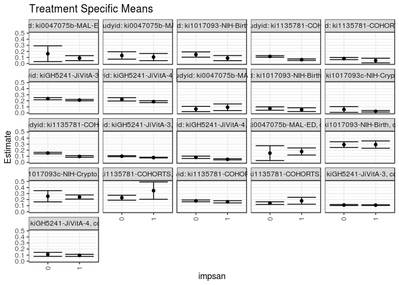

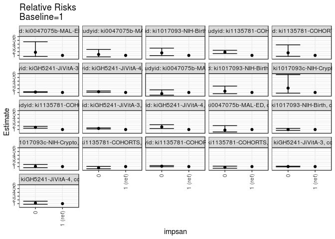

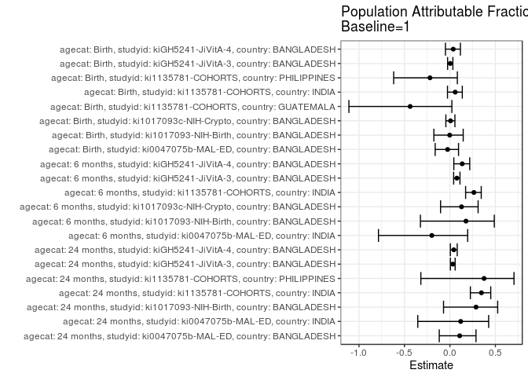

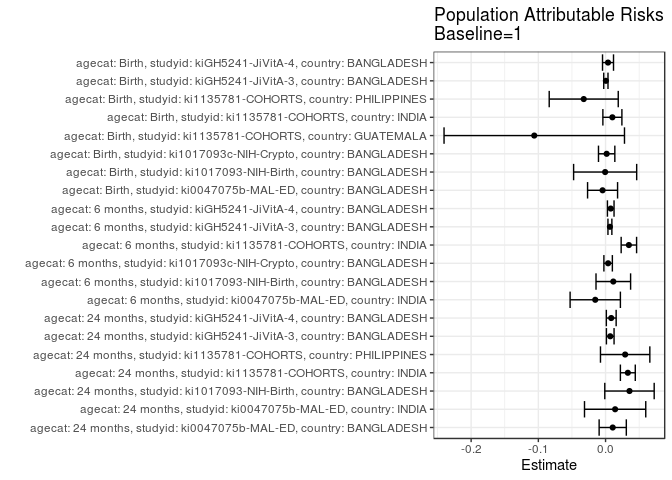

## Results Table

### Parameter: TSM

| agecat | studyid | country | intervention_level | baseline_level | estimate | ci_lower | ci_upper |
| --- | --- | --- | --- | --- | --- | --- | --- |
| Birth | ki0047075b-MAL-ED | BANGLADESH | 1 | NA | 0.1785714 | 0.1205127 | 0.2366301 |
| Birth | ki0047075b-MAL-ED | BANGLADESH | 0 | NA | 0.1515152 | 0.0288774 | 0.2741529 |
| Birth | ki1017093-NIH-Birth | BANGLADESH | 1 | NA | 0.2927928 | 0.2328823 | 0.3527033 |
| Birth | ki1017093-NIH-Birth | BANGLADESH | 0 | NA | 0.2917847 | 0.2443220 | 0.3392474 |
| Birth | ki1017093c-NIH-Crypto | BANGLADESH | 1 | NA | 0.2426230 | 0.2085808 | 0.2766651 |
| Birth | ki1017093c-NIH-Crypto | BANGLADESH | 0 | NA | 0.2558140 | 0.1635326 | 0.3480953 |
| Birth | ki1135781-COHORTS | GUATEMALA | 1 | NA | 0.3488372 | 0.2062258 | 0.4914486 |
| Birth | ki1135781-COHORTS | GUATEMALA | 0 | NA | 0.2315271 | 0.1904514 | 0.2726027 |
| Birth | ki1135781-COHORTS | INDIA | 1 | NA | 0.1637982 | 0.1461254 | 0.1814711 |
| Birth | ki1135781-COHORTS | INDIA | 0 | NA | 0.1801153 | 0.1658185 | 0.1944121 |
| Birth | ki1135781-COHORTS | PHILIPPINES | 1 | NA | 0.1807910 | 0.1240705 | 0.2375115 |
| Birth | ki1135781-COHORTS | PHILIPPINES | 0 | NA | 0.1422550 | 0.1200208 | 0.1644892 |
| Birth | kiGH5241-JiVitA-3 | BANGLADESH | 1 | NA | 0.1091598 | 0.1030150 | 0.1153045 |
| Birth | kiGH5241-JiVitA-3 | BANGLADESH | 0 | NA | 0.1106131 | 0.1020835 | 0.1191427 |
| Birth | kiGH5241-JiVitA-4 | BANGLADESH | 1 | NA | 0.0957504 | 0.0787287 | 0.1127721 |
| Birth | kiGH5241-JiVitA-4 | BANGLADESH | 0 | NA | 0.1121495 | 0.0791887 | 0.1451104 |
| 6 months | ki0047075b-MAL-ED | INDIA | 1 | NA | 0.0925926 | 0.0378079 | 0.1473773 |
| 6 months | ki0047075b-MAL-ED | INDIA | 0 | NA | 0.0640000 | 0.0210013 | 0.1069987 |
| 6 months | ki1017093-NIH-Birth | BANGLADESH | 1 | NA | 0.0536585 | 0.0227827 | 0.0845344 |
| 6 months | ki1017093-NIH-Birth | BANGLADESH | 0 | NA | 0.0722892 | 0.0444070 | 0.1001713 |
| 6 months | ki1017093c-NIH-Crypto | BANGLADESH | 1 | NA | 0.0260163 | 0.0134265 | 0.0386060 |
| 6 months | ki1017093c-NIH-Crypto | BANGLADESH | 0 | NA | 0.0561798 | 0.0083061 | 0.1040534 |
| 6 months | ki1135781-COHORTS | INDIA | 1 | NA | 0.0968600 | 0.0834855 | 0.1102346 |
| 6 months | ki1135781-COHORTS | INDIA | 0 | NA | 0.1526742 | 0.1399810 | 0.1653675 |
| 6 months | kiGH5241-JiVitA-3 | BANGLADESH | 1 | NA | 0.0780691 | 0.0724511 | 0.0836870 |
| 6 months | kiGH5241-JiVitA-3 | BANGLADESH | 0 | NA | 0.1008827 | 0.0921151 | 0.1096504 |
| 6 months | kiGH5241-JiVitA-4 | BANGLADESH | 1 | NA | 0.0492769 | 0.0394688 | 0.0590851 |
| 6 months | kiGH5241-JiVitA-4 | BANGLADESH | 0 | NA | 0.0832571 | 0.0640503 | 0.1024639 |
| 24 months | ki0047075b-MAL-ED | BANGLADESH | 1 | NA | 0.0883978 | 0.0469445 | 0.1298511 |
| 24 months | ki0047075b-MAL-ED | BANGLADESH | 0 | NA | 0.1612903 | 0.0315115 | 0.2910692 |
| 24 months | ki0047075b-MAL-ED | INDIA | 1 | NA | 0.1057692 | 0.0465309 | 0.1650076 |
| 24 months | ki0047075b-MAL-ED | INDIA | 0 | NA | 0.1322314 | 0.0717402 | 0.1927226 |
| 24 months | ki1017093-NIH-Birth | BANGLADESH | 1 | NA | 0.0882353 | 0.0455484 | 0.1309221 |
| 24 months | ki1017093-NIH-Birth | BANGLADESH | 0 | NA | 0.1472868 | 0.1039926 | 0.1905810 |
| 24 months | ki1135781-COHORTS | INDIA | 1 | NA | 0.0624571 | 0.0500302 | 0.0748840 |
| 24 months | ki1135781-COHORTS | INDIA | 0 | NA | 0.1168946 | 0.1036669 | 0.1301223 |
| 24 months | ki1135781-COHORTS | PHILIPPINES | 1 | NA | 0.0483871 | 0.0105994 | 0.0861748 |
| 24 months | ki1135781-COHORTS | PHILIPPINES | 0 | NA | 0.0817031 | 0.0634823 | 0.0999239 |
| 24 months | kiGH5241-JiVitA-3 | BANGLADESH | 1 | NA | 0.2110107 | 0.1998355 | 0.2221859 |
| 24 months | kiGH5241-JiVitA-3 | BANGLADESH | 0 | NA | 0.2348485 | 0.2174895 | 0.2522075 |
| 24 months | kiGH5241-JiVitA-4 | BANGLADESH | 1 | NA | 0.1860528 | 0.1707601 | 0.2013456 |
| 24 months | kiGH5241-JiVitA-4 | BANGLADESH | 0 | NA | 0.2237960 | 0.1958688 | 0.2517233 |

### Parameter: E(Y)

| agecat | studyid | country | intervention_level | baseline_level | estimate | ci_lower | ci_upper |
| --- | --- | --- | --- | --- | --- | --- | --- |
| Birth | ki0047075b-MAL-ED | BANGLADESH | NA | NA | 0.1741294 | 0.1215730 | 0.2266857 |
| Birth | ki1017093-NIH-Birth | BANGLADESH | NA | NA | 0.2921739 | 0.2549711 | 0.3293768 |
| Birth | ki1017093c-NIH-Crypto | BANGLADESH | NA | NA | 0.2442529 | 0.2123108 | 0.2761950 |
| Birth | ki1135781-COHORTS | GUATEMALA | NA | NA | 0.2427617 | 0.2030594 | 0.2824640 |
| Birth | ki1135781-COHORTS | INDIA | NA | NA | 0.1739520 | 0.1628271 | 0.1850770 |
| Birth | ki1135781-COHORTS | PHILIPPINES | NA | NA | 0.1483126 | 0.1275443 | 0.1690809 |
| Birth | kiGH5241-JiVitA-3 | BANGLADESH | NA | NA | 0.1096104 | 0.1044820 | 0.1147387 |
| Birth | kiGH5241-JiVitA-4 | BANGLADESH | NA | NA | 0.0994152 | 0.0840401 | 0.1147903 |
| 6 months | ki0047075b-MAL-ED | INDIA | NA | NA | 0.0772532 | 0.0428971 | 0.1116093 |
| 6 months | ki1017093-NIH-Birth | BANGLADESH | NA | NA | 0.0651769 | 0.0442802 | 0.0860736 |
| 6 months | ki1017093c-NIH-Crypto | BANGLADESH | NA | NA | 0.0298295 | 0.0172543 | 0.0424048 |
| 6 months | ki1135781-COHORTS | INDIA | NA | NA | 0.1315471 | 0.1221436 | 0.1409506 |
| 6 months | kiGH5241-JiVitA-3 | BANGLADESH | NA | NA | 0.0845406 | 0.0797299 | 0.0893513 |
| 6 months | kiGH5241-JiVitA-4 | BANGLADESH | NA | NA | 0.0569712 | 0.0481278 | 0.0658146 |
| 24 months | ki0047075b-MAL-ED | BANGLADESH | NA | NA | 0.0990566 | 0.0587480 | 0.1393652 |
| 24 months | ki0047075b-MAL-ED | INDIA | NA | NA | 0.1200000 | 0.0774445 | 0.1625555 |
| 24 months | ki1017093-NIH-Birth | BANGLADESH | NA | NA | 0.1238318 | 0.0925894 | 0.1550741 |
| 24 months | ki1135781-COHORTS | INDIA | NA | NA | 0.0955961 | 0.0861511 | 0.1050412 |
| 24 months | ki1135781-COHORTS | PHILIPPINES | NA | NA | 0.0775428 | 0.0608996 | 0.0941860 |
| 24 months | kiGH5241-JiVitA-3 | BANGLADESH | NA | NA | 0.2179681 | 0.2080916 | 0.2278446 |
| 24 months | kiGH5241-JiVitA-4 | BANGLADESH | NA | NA | 0.1945032 | 0.1812962 | 0.2077102 |

### Parameter: RR

| agecat | studyid | country | intervention_level | baseline_level | estimate | ci_lower | ci_upper |
| --- | --- | --- | --- | --- | --- | --- | --- |
| Birth | ki0047075b-MAL-ED | BANGLADESH | 1 | 1 | 1.0000000 | 1.0000000 | 1.000000 |
| Birth | ki0047075b-MAL-ED | BANGLADESH | 0 | 1 | 0.8484848 | 0.3546686 | 2.029857 |
| Birth | ki1017093-NIH-Birth | BANGLADESH | 1 | 1 | 1.0000000 | 1.0000000 | 1.000000 |
| Birth | ki1017093-NIH-Birth | BANGLADESH | 0 | 1 | 0.9965570 | 0.7673251 | 1.294270 |
| Birth | ki1017093c-NIH-Crypto | BANGLADESH | 1 | 1 | 1.0000000 | 1.0000000 | 1.000000 |
| Birth | ki1017093c-NIH-Crypto | BANGLADESH | 0 | 1 | 1.0543683 | 0.7159675 | 1.552714 |
| Birth | ki1135781-COHORTS | GUATEMALA | 1 | 1 | 1.0000000 | 1.0000000 | 1.000000 |
| Birth | ki1135781-COHORTS | GUATEMALA | 0 | 1 | 0.6637110 | 0.4250437 | 1.036393 |
| Birth | ki1135781-COHORTS | INDIA | 1 | 1 | 1.0000000 | 1.0000000 | 1.000000 |
| Birth | ki1135781-COHORTS | INDIA | 0 | 1 | 1.0996168 | 0.9617654 | 1.257227 |
| Birth | ki1135781-COHORTS | PHILIPPINES | 1 | 1 | 1.0000000 | 1.0000000 | 1.000000 |
| Birth | ki1135781-COHORTS | PHILIPPINES | 0 | 1 | 0.7868480 | 0.5541984 | 1.117163 |
| Birth | kiGH5241-JiVitA-3 | BANGLADESH | 1 | 1 | 1.0000000 | 1.0000000 | 1.000000 |
| Birth | kiGH5241-JiVitA-3 | BANGLADESH | 0 | 1 | 1.0133142 | 0.9235798 | 1.111767 |
| Birth | kiGH5241-JiVitA-4 | BANGLADESH | 1 | 1 | 1.0000000 | 1.0000000 | 1.000000 |
| Birth | kiGH5241-JiVitA-4 | BANGLADESH | 0 | 1 | 1.1712696 | 0.8353754 | 1.642223 |
| 6 months | ki0047075b-MAL-ED | INDIA | 1 | 1 | 1.0000000 | 1.0000000 | 1.000000 |
| 6 months | ki0047075b-MAL-ED | INDIA | 0 | 1 | 0.6912000 | 0.2823598 | 1.692017 |
| 6 months | ki1017093-NIH-Birth | BANGLADESH | 1 | 1 | 1.0000000 | 1.0000000 | 1.000000 |
| 6 months | ki1017093-NIH-Birth | BANGLADESH | 0 | 1 | 1.3472070 | 0.6738877 | 2.693278 |
| 6 months | ki1017093c-NIH-Crypto | BANGLADESH | 1 | 1 | 1.0000000 | 1.0000000 | 1.000000 |
| 6 months | ki1017093c-NIH-Crypto | BANGLADESH | 0 | 1 | 2.1594101 | 0.8104761 | 5.753473 |
| 6 months | ki1135781-COHORTS | INDIA | 1 | 1 | 1.0000000 | 1.0000000 | 1.000000 |
| 6 months | ki1135781-COHORTS | INDIA | 0 | 1 | 1.5762356 | 1.3415974 | 1.851911 |
| 6 months | kiGH5241-JiVitA-3 | BANGLADESH | 1 | 1 | 1.0000000 | 1.0000000 | 1.000000 |
| 6 months | kiGH5241-JiVitA-3 | BANGLADESH | 0 | 1 | 1.2922238 | 1.1569968 | 1.443256 |
| 6 months | kiGH5241-JiVitA-4 | BANGLADESH | 1 | 1 | 1.0000000 | 1.0000000 | 1.000000 |
| 6 months | kiGH5241-JiVitA-4 | BANGLADESH | 0 | 1 | 1.6895759 | 1.2491036 | 2.285372 |
| 24 months | ki0047075b-MAL-ED | BANGLADESH | 1 | 1 | 1.0000000 | 1.0000000 | 1.000000 |
| 24 months | ki0047075b-MAL-ED | BANGLADESH | 0 | 1 | 1.8245968 | 0.7189612 | 4.630505 |
| 24 months | ki0047075b-MAL-ED | INDIA | 1 | 1 | 1.0000000 | 1.0000000 | 1.000000 |
| 24 months | ki0047075b-MAL-ED | INDIA | 0 | 1 | 1.2501878 | 0.6066144 | 2.576545 |
| 24 months | ki1017093-NIH-Birth | BANGLADESH | 1 | 1 | 1.0000000 | 1.0000000 | 1.000000 |
| 24 months | ki1017093-NIH-Birth | BANGLADESH | 0 | 1 | 1.6692506 | 0.9477079 | 2.940144 |
| 24 months | ki1135781-COHORTS | INDIA | 1 | 1 | 1.0000000 | 1.0000000 | 1.000000 |
| 24 months | ki1135781-COHORTS | INDIA | 0 | 1 | 1.8715977 | 1.4886914 | 2.352991 |
| 24 months | ki1135781-COHORTS | PHILIPPINES | 1 | 1 | 1.0000000 | 1.0000000 | 1.000000 |
| 24 months | ki1135781-COHORTS | PHILIPPINES | 0 | 1 | 1.6885309 | 0.7495319 | 3.803889 |
| 24 months | kiGH5241-JiVitA-3 | BANGLADESH | 1 | 1 | 1.0000000 | 1.0000000 | 1.000000 |
| 24 months | kiGH5241-JiVitA-3 | BANGLADESH | 0 | 1 | 1.1129696 | 1.0214971 | 1.212633 |
| 24 months | kiGH5241-JiVitA-4 | BANGLADESH | 1 | 1 | 1.0000000 | 1.0000000 | 1.000000 |
| 24 months | kiGH5241-JiVitA-4 | BANGLADESH | 0 | 1 | 1.2028627 | 1.0323736 | 1.401507 |

### Parameter: PAR

| agecat | studyid | country | intervention_level | baseline_level | estimate | ci_lower | ci_upper |
| --- | --- | --- | --- | --- | --- | --- | --- |
| Birth | ki0047075b-MAL-ED | BANGLADESH | 1 | NA | -0.0044421 | -0.0267622 | 0.0178781 |
| Birth | ki1017093-NIH-Birth | BANGLADESH | 1 | NA | -0.0006189 | -0.0475420 | 0.0463043 |
| Birth | ki1017093c-NIH-Crypto | BANGLADESH | 1 | NA | 0.0016299 | -0.0105281 | 0.0137879 |
| Birth | ki1135781-COHORTS | GUATEMALA | 1 | NA | -0.1060755 | -0.2403097 | 0.0281586 |
| Birth | ki1135781-COHORTS | INDIA | 1 | NA | 0.0101538 | -0.0039936 | 0.0243012 |
| Birth | ki1135781-COHORTS | PHILIPPINES | 1 | NA | -0.0324783 | -0.0838309 | 0.0188742 |
| Birth | kiGH5241-JiVitA-3 | BANGLADESH | 1 | NA | 0.0004506 | -0.0027159 | 0.0036172 |
| Birth | kiGH5241-JiVitA-4 | BANGLADESH | 1 | NA | 0.0036648 | -0.0045087 | 0.0118383 |
| 6 months | ki0047075b-MAL-ED | INDIA | 1 | NA | -0.0153394 | -0.0527469 | 0.0220682 |
| 6 months | ki1017093-NIH-Birth | BANGLADESH | 1 | NA | 0.0115184 | -0.0142135 | 0.0372503 |
| 6 months | ki1017093c-NIH-Crypto | BANGLADESH | 1 | NA | 0.0038133 | -0.0024884 | 0.0101150 |
| 6 months | ki1135781-COHORTS | INDIA | 1 | NA | 0.0346871 | 0.0232030 | 0.0461712 |
| 6 months | kiGH5241-JiVitA-3 | BANGLADESH | 1 | NA | 0.0064716 | 0.0035604 | 0.0093827 |
| 6 months | kiGH5241-JiVitA-4 | BANGLADESH | 1 | NA | 0.0076943 | 0.0027751 | 0.0126135 |
| 24 months | ki0047075b-MAL-ED | BANGLADESH | 1 | NA | 0.0106588 | -0.0095637 | 0.0308813 |
| 24 months | ki0047075b-MAL-ED | INDIA | 1 | NA | 0.0142308 | -0.0313336 | 0.0597951 |
| 24 months | ki1017093-NIH-Birth | BANGLADESH | 1 | NA | 0.0355965 | -0.0011559 | 0.0723489 |
| 24 months | ki1135781-COHORTS | INDIA | 1 | NA | 0.0331390 | 0.0220576 | 0.0442204 |
| 24 months | ki1135781-COHORTS | PHILIPPINES | 1 | NA | 0.0291557 | -0.0075634 | 0.0658748 |
| 24 months | kiGH5241-JiVitA-3 | BANGLADESH | 1 | NA | 0.0069574 | 0.0012684 | 0.0126465 |
| 24 months | kiGH5241-JiVitA-4 | BANGLADESH | 1 | NA | 0.0084503 | 0.0011469 | 0.0157538 |

### Parameter: PAF

| agecat | studyid | country | intervention_level | baseline_level | estimate | ci_lower | ci_upper |
| --- | --- | --- | --- | --- | --- | --- | --- |
| Birth | ki0047075b-MAL-ED | BANGLADESH | 1 | NA | -0.0255102 | -0.1618982 | 0.0948681 |
| Birth | ki1017093-NIH-Birth | BANGLADESH | 1 | NA | -0.0021182 | -0.1763030 | 0.1462737 |
| Birth | ki1017093c-NIH-Crypto | BANGLADESH | 1 | NA | 0.0066731 | -0.0443685 | 0.0552201 |
| Birth | ki1135781-COHORTS | GUATEMALA | 1 | NA | -0.4369533 | -1.1108206 | 0.0217858 |
| Birth | ki1135781-COHORTS | INDIA | 1 | NA | 0.0583713 | -0.0265173 | 0.1362400 |
| Birth | ki1135781-COHORTS | PHILIPPINES | 1 | NA | -0.2189858 | -0.6183730 | 0.0818394 |
| Birth | kiGH5241-JiVitA-3 | BANGLADESH | 1 | NA | 0.0041110 | -0.0252106 | 0.0325940 |
| Birth | kiGH5241-JiVitA-4 | BANGLADESH | 1 | NA | 0.0368636 | -0.0488463 | 0.1155694 |
| 6 months | ki0047075b-MAL-ED | INDIA | 1 | NA | -0.1985597 | -0.7855318 | 0.1954524 |
| 6 months | ki1017093-NIH-Birth | BANGLADESH | 1 | NA | 0.1767247 | -0.3240464 | 0.4880979 |
| 6 months | ki1017093c-NIH-Crypto | BANGLADESH | 1 | NA | 0.1278358 | -0.1028159 | 0.3102472 |
| 6 months | ki1135781-COHORTS | INDIA | 1 | NA | 0.2636857 | 0.1727940 | 0.3445905 |
| 6 months | kiGH5241-JiVitA-3 | BANGLADESH | 1 | NA | 0.0765496 | 0.0411884 | 0.1106067 |
| 6 months | kiGH5241-JiVitA-4 | BANGLADESH | 1 | NA | 0.1350558 | 0.0431001 | 0.2181747 |
| 24 months | ki0047075b-MAL-ED | BANGLADESH | 1 | NA | 0.1076033 | -0.1170077 | 0.2870488 |
| 24 months | ki0047075b-MAL-ED | INDIA | 1 | NA | 0.1185897 | -0.3533005 | 0.4259338 |
| 24 months | ki1017093-NIH-Birth | BANGLADESH | 1 | NA | 0.2874584 | -0.0698917 | 0.5254514 |
| 24 months | ki1135781-COHORTS | INDIA | 1 | NA | 0.3466566 | 0.2251094 | 0.4491382 |
| 24 months | ki1135781-COHORTS | PHILIPPINES | 1 | NA | 0.3759950 | -0.3196083 | 0.7049259 |
| 24 months | kiGH5241-JiVitA-3 | BANGLADESH | 1 | NA | 0.0319195 | 0.0054895 | 0.0576471 |
| 24 months | kiGH5241-JiVitA-4 | BANGLADESH | 1 | NA | 0.0434457 | 0.0049326 | 0.0804681 |